# A3: Incarceration

### Introduction

```r
library(tidyverse)
```

```r
library(dplyr)
library(ggplot2)

jail_population_per_county_state <- read.csv("https://raw.githubusercontent.com/melaniewalsh/Neat-Datasets/main/us-jail-pop.csv")
```

The problem domain for this dataset centers on the dynamics of incarceration in the U.S. Some key aspects of this problem domain would be Incarceration Rates, Demographic Disparities, Policy Impacts etc. The variable I’m going to choose to analyze would be:

- `year` = Year
- `state` = State name
- `county_name` = County name
- `urbanicity` = Urbanicity
- `total_jail_pop` = Total jail population count, ASJ/COJ data
- `female_jail_pop` = Female jail population count, ASJ/COJ data
- `male_jail_pop` = Male jail population count, ASJ/COJ data
- `black_jail_pop`, `white_jail_pop` = Different race in jail population count

By analyzing `state`, `county_name` and `urbanicity`, it could show us how different different places compare in terms of incarceration rates.

By analyzing `year` and `total_jail_pop`, it can help us to identify the trends over the years, including increases or decreases in jail populations, which could be correlated with policy changes, crime rates, or social conditions.

By analyzing `female_jail_pop` and `male_jail_pop`, it can provide us with the insights into the composition of the jail population and highlight any disproportionate impacts on specific groups of people, such as the gender differences in incarceration rates.

By analyzing `black_jail_pop`, `white_jail_pop`, it would allow us to assess the impact of racial bias and systemic discrimination.

### Summary Information

```r
mean_white_jail_pop <- mean(jail_population_per_county_state$white_jail_pop, na.rm = TRUE)
max_white_jail_pop <- max(jail_population_per_county_state$white_jail_pop, na.rm = TRUE)
min_white_jail_pop <- min(jail_population_per_county_state$white_jail_pop, na.rm = TRUE)

mean_black_jail_pop <- mean(jail_population_per_county_state$black_jail_pop, na.rm = TRUE)
max_black_jail_pop <- max(jail_population_per_county_state$black_jail_pop, na.rm = TRUE)
min_black_jail_pop <- min(jail_population_per_county_state$black_jail_pop, na.rm = TRUE)

white_in_last_10_years <- max(jail_population_per_county_state$year) - 9
data_for_last_10_years_white <- jail_population_per_county_state %>%
  filter(year >= white_in_last_10_years)

initial_white_population <- data_for_last_10_years_white %>%
  filter(year == min(year)) %>%
  summarize(initial_pop = mean(white_jail_pop, na.rm = TRUE))

final_white_population <- data_for_last_10_years_white %>%
  filter(year == max(year)) %>%
  summarize(final_pop = mean(white_jail_pop, na.rm = TRUE))

white_jail_population_change <- final_white_population$final_pop - initial_white_population$initial_pop

black_in_last_10_years <- max(jail_population_per_county_state$year) - 9
data_for_last_10_years_black <- jail_population_per_county_state %>%
  filter(year >= black_in_last_10_years)

initial_black_population <- data_for_last_10_years_black %>%
  filter(year == min(year)) %>%
  summarize(initial_pop = mean(white_jail_pop, na.rm = TRUE))

final_black_population <- data_for_last_10_years_black %>%
  filter(year == max(year)) %>%
  summarize(final_pop = mean(black_jail_pop, na.rm = TRUE))

black_jail_population_change <- final_black_population$final_pop - initial_black_population$initial_pop
```

```r
mean_female_jail_pop <- mean(jail_population_per_county_state$female_jail_pop, na.rm = TRUE)
max_female_jail_pop <- max(jail_population_per_county_state$female_jail_pop, na.rm = TRUE)
min_female_jail_pop <- min(jail_population_per_county_state$female_jail_pop, na.rm = TRUE)

mean_male_jail_pop <- mean(jail_population_per_county_state$male_jail_pop, na.rm = TRUE)
max_male_jail_pop <- max(jail_population_per_county_state$male_jail_pop, na.rm = TRUE)
min_male_jail_pop <- min(jail_population_per_county_state$male_jail_pop, na.rm = TRUE)

female_in_last_10_years <- max(jail_population_per_county_state$year) - 9
data_for_last_10_years_female <- jail_population_per_county_state %>%
  filter(year >= female_in_last_10_years)

initial_female_population <- data_for_last_10_years_female %>%
  filter(year == min(year)) %>%
  summarize(initial_pop = mean(female_jail_pop, na.rm = TRUE))

final_female_population <- data_for_last_10_years_female %>%
  filter(year == max(year)) %>%
  summarize(final_pop = mean(female_jail_pop, na.rm = TRUE))

female_jail_population_change <- final_female_population$final_pop - initial_female_population$initial_pop

male_in_last_10_years <- max(jail_population_per_county_state$year) - 9
data_for_last_10_years_male <- jail_population_per_county_state %>%
  filter(year >= male_in_last_10_years)

initial_male_population <- data_for_last_10_years_male %>%
  filter(year == min(year)) %>%
  summarize(initial_pop = mean(male_jail_pop, na.rm = TRUE))

final_male_population <- data_for_last_10_years_male %>%
  filter(year == max(year)) %>%
  summarize(final_pop = mean(male_jail_pop, na.rm = TRUE))

male_jail_population_change <- final_male_population$final_pop - initial_male_population$initial_pop
```

From the calculated data given above, we could easily find that female has a much lower mean in the jail population than male, which is about 18.21043, and male has 143.6055. And also the maximum both gender provides is largely different, female has the data with the maximum number of 2897.41, on the other hand, male has 20288.14. Also as the calculation between the maximum and the minimum for both gender, we could find that female’s change in jail population is about 3.056593, and surprisingly the male’s change in jail population is -17.76798, which means male’s jail population is decreasing over times.

### The Dataset

- Vera Institute is the one who collected the data.
- The specific method that was used by the Vera Institute is to collect those data typically involves gathering public records from various sources, including local, state, and federal law enforcement and judicial agencies.
- I believe the purpose of collecting this data would be to analyze, understand, and expose the impacts of the criminal justice system, particularly focusing on issues like mass incarceration, racial disparities, and the effects of policy changes. By doing this, can help to build a more equitable legal system.

```r
jail_pop_rows <- nrow(jail_population_per_county_state)
print(jail_pop_rows)
```

```
## [1] 153811
```

- There are total 153811 observations are in this dataset.

```r
jail_pop_cols <- ncol(jail_population_per_county_state)
print(jail_pop_cols)
```

```
## [1] 28
```

- There are total 28 features are in this dataset.
- While analyzing this dataset, I’ve think of some questions that I believe that I need to consider on some ethical questions or questions of power, and it’s basically centered in personal privacy and confidentiality. Since this dataset is pretty sensitive(because it relates to personal information and the laws), thus we have to ensure that individual identities are protected. On the other hand, I should also consider the Bias in the dataset, there will and must be bias in different places, thus I have to consider more on if there are biases in which groups(especially in different race groups) are being more heavily supervised or reported.
- The possible limitations or problems with this data I think would probably be the data’s completeness and accuracy. Since, Vera Consitute actually collected these data from seperate organizations, it’s very possible that the data could vary in accuracy and completeness, which would lead to gaps or biases in this dataset. On the other hand, I think there would be variations in each places, every places have there own differences in laws, enforcement practices, and social conditions, and this can make it challenging to summarize and analyze the whole data itself. Also, from my perspective, I think there would be changes in the reporting standard over times, and this would definitely cause influence on longitudinal analyses and make comparisons over time less reliable.

### Trends Over Time Chart

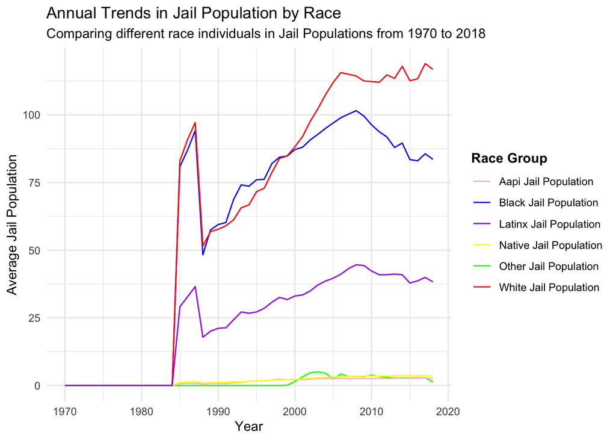

```r
annual_trends <- jail_population_per_county_state %>%
  group_by(year) %>%
  summarise(
    average_black_population = mean(black_jail_pop, na.rm = TRUE),
    average_white_population = mean(white_jail_pop, na.rm = TRUE),
    average_other_race_population = mean(other_race_jail_pop, na.rm = TRUE),
    average_aapi_population = mean(aapi_jail_pop, na.rm = TRUE),
    average_native_population = mean(native_jail_pop, na.rm = TRUE),
    average_latinx_population = mean(latinx_jail_pop, na.rm = TRUE)
  )

ggplot(annual_trends, aes(x = year)) +
  geom_line(aes(y = average_black_population, color = "Black Jail Population")) +
  geom_line(aes(y = average_white_population, color = "White Jail Population")) +
  geom_line(aes(y = average_other_race_population, color = "Other Jail Population")) +
  geom_line(aes(y = average_aapi_population, color = "Aapi Jail Population")) +
  geom_line(aes(y = average_native_population, color = "Native Jail Population")) +
  geom_line(aes(y = average_latinx_population, color = "Latinx Jail Population")) +
  scale_color_manual(values = c("Black Jail Population" = "blue", "White Jail Population" = "red", "Other Jail Population" = "green", "Aapi Jail Population" = "pink", "Native Jail Population" = "yellow", "Latinx Jail Population" = "purple")) +
  labs(title = "Annual Trends in Jail Population by Race",
       subtitle = "Comparing different race individuals in Jail Populations from 1970 to 2018",
       x = "Year",
       y = "Average Jail Population",
       color = "Race Group") +
  theme_minimal() +
  theme(legend.title = element_text(face = "bold"))
```

The chart was included to visually represent the trends in jail populations across different races from 1970 to 2018. The purpose of illustrating these trends is to highlight differences and patterns in incarceration rates that may reflect underlying social, economic, or legislative factors affecting different racial groups. From the pattern the chart has showed, it seems white and black’s individuals have higher incarceration rates over the years compared to other races. This trend somehow showcases the ongoing issues related to racial profiling, sentencing policies etc, within the criminal justice system. On the other hand, we could see the AAPI and OTHER RACES shows almost “flat” trend on this chart, it probably indicate some specific issues or disparities that these groups of individuals are not widely recognized.

### Variable Comparison Chart

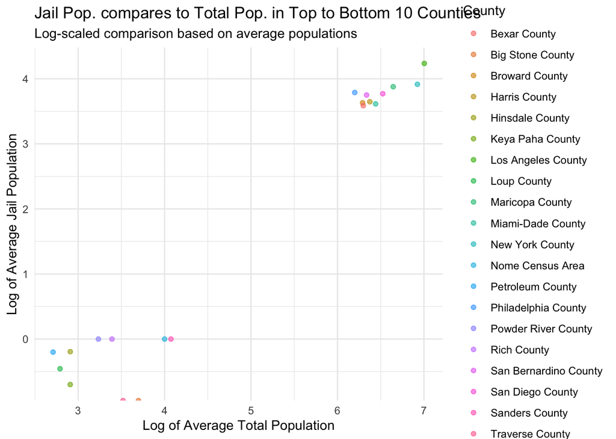

```r
most_recent_data <- jail_population_per_county_state %>%
  filter(year == max(year)) %>%
  select(county_name, total_pop, total_jail_pop) %>%
  group_by(county_name) %>%
  summarise(
    average_total_population = mean(total_pop, na.rm = TRUE),
    average_jail_population = mean(total_jail_pop, na.rm = TRUE)
  ) %>%
  na.omit()

top_bottom_counties <- most_recent_data%>%
  arrange(desc(average_jail_population)) %>%
  slice(c(1:10, (n()-9):n()))

ggplot(top_bottom_counties, aes(x = log10(average_total_population), y = log10(average_jail_population))) +
  geom_point(aes(color = county_name), alpha = 0.6) +
  labs(
    title = "Jail Pop. compares to Total Pop. in Top to Bottom 10 Counties",
    subtitle = "Log-scaled comparison based on average populations",
    x = "Log of Average Total Population",
    y = "Log of Average Jail Population",
    color = "County"
  ) +
  theme_minimal() +
  theme(legend.position = "right")
```

### Map

[figure not shown]

```r
jail_population_per_county_state <- data.frame(
  state_code = c("CA", "AZ", "NY", "TX"),
  total_jail_pop = c(10000, 8000, 9000, 15000)
)

state_names <- tibble(state_code = c("CA", "AZ", "NY", "TX"),
                      state_name = c("california", "arizona", "new york", "texas"))

jail_population_per_county_state <- jail_population_per_county_state %>%
  left_join(state_names, by = "state_code")

states_map <- map_data("state")

map_data <- left_join(states_map, jail_population_per_county_state, by = c("region" = "state_name"))


ggplot(data = map_data, mapping = aes(x = long, y = lat, group = group, fill = total_jail_pop)) +
  geom_polygon(color = "white") +
  scale_fill_viridis_c(name = "Jail Population", option = "C") +
  labs(title = "Jail Population by State", subtitle = "Data based on the most recent year") +
  coord_fixed(1.3) +
  theme_minimal() +
  theme(legend.position = "right")
```